# KMeans Assignment

### Basically it translates to:

#Cluster 2 contains - Universities with few applications, low acceptance, low enrollment, very few students from top 10, very few students from top 25, few number of FT and PT undergrad, low in-state and out of state tuiton fee, very few rooms, small board of members and very low additional fee, book costs and personal expenses. It also has very few faculty with PHD, average student faculty ratio and a very low graduation rate.

#Cluster 3 contains - Universities with average no of applications received, average acceptance, average enrollment, high no of students from top 10, high number of students from top 25, low number of FT and PT undergrad, very high in-state and out of state tuiton fee, very large no. of rooms, big board of members and low additional fee, book costs and personal expenses. It also has a high number of faculty with PHD, a low student faculty ratio and a high graduation rate.

### Part 4 - Use the categorical measurements that were not used in the analysis (State and Private/Public) to characterize the different clusters. Is there any relationship between the clusters and the categorical information?

#### Creating another dataset with just state and public..1private..2. column and adding clusters also in that dataset to see the relationship between them.

```r
Clusterdata <- Universitydata
Clusterdata <- na.omit(Clusterdata)

University_cluster <- select(Clusterdata, State, Public..1...Private..2.)

University_cluster <- data.frame(University_cluster,
  cluster = as.factor(k3$cluster)
)
```

#### Now let’s plot between Public..1Private..2. and Cluster

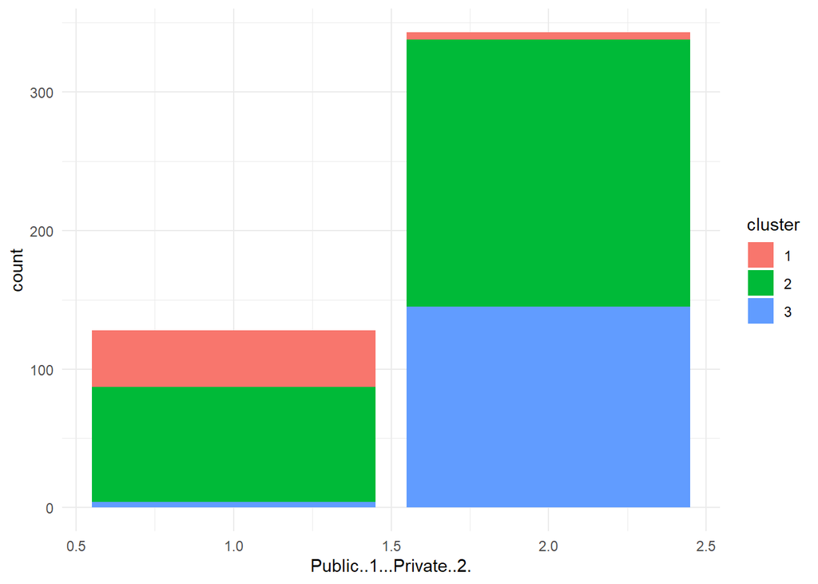

```r
ggplot(University_cluster) +
 aes(x = Public..1...Private..2., fill = cluster) +
 geom_bar() +
 scale_fill_hue() +
 theme_minimal()
```

#There is a relationship between the clusters and the categorical information as mentioned above. From my understanding, it looks like: #Cluster 1 - Really good Public Universities #Cluster 2 - Combination of good Public Universities and average Private Universities. #Cluster 3 - Ivy Leagues or huge Private Universities

#### Now let’s plot between State, Cluster and no. of Public and Private Universities.

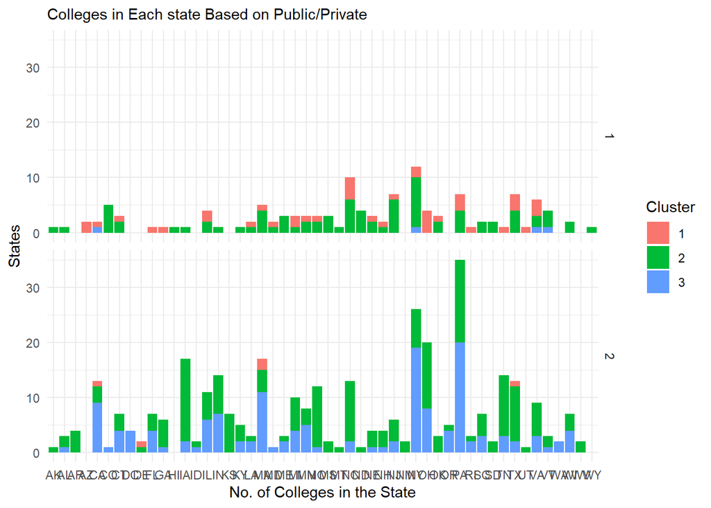

```r
ggplot(University_cluster) +
 aes(x = State, fill = cluster) +
 geom_bar() +
 scale_fill_hue() +
 labs(x = "No. of Colleges in the State", y = "States", subtitle = "Colleges in Each state Based on Public/Private", fill = "Cluster") +
 theme_minimal() +
 facet_grid(vars(Public..1...Private..2.), vars())
```

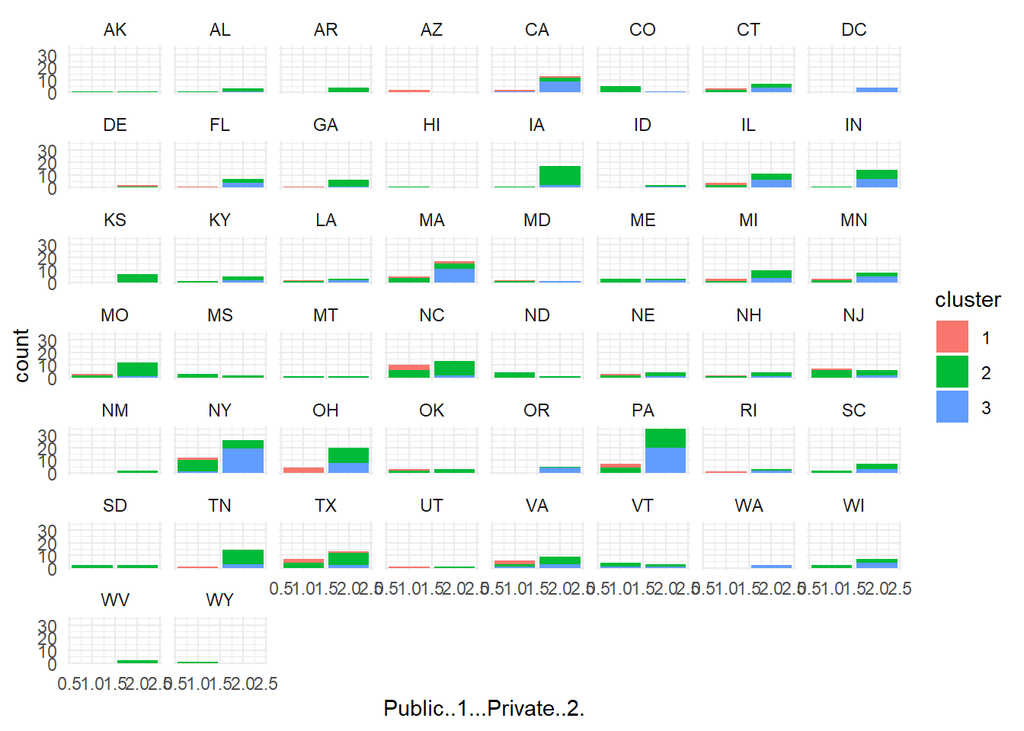

```r
#Another way to look at this information since states are not visible properly.
ggplot(University_cluster) +
 aes(x = Public..1...Private..2., fill = cluster) +
 geom_bar() +
 scale_fill_hue() +
 theme_minimal() +
 facet_wrap(vars(State))
```

#Cluster 1 also has Universities mostly in major states. #Cluster 2 has universities across almost every state including Wyoming and Alaska #Cluster 3 has universities in major states

### Part 5 - What other external information can explain the contents of some or all of these clusters?

External Information like State Funding, Size of state, Population of state, Household income of that state can also explain these clusters.

### Part 6 - Consider Tufts University, which is missing some information. Compute the Euclidean distance of this record from each of the clusters that you found above (using only the measurements that you have). Which cluster is it closest to? Impute the missing values for Tufts by taking the average of the cluster on those measurements.

#### Getting the data we need.

```r
#tufts university is record no 476 is our dataset. This is our test data.
Universitydata_test <- Universitydata_scaled[476,]

#Let's see what values are null in this record.
Universitydata_test
```

```
##           X..appli..rec.d         X..appl..accepted     X..new.stud..enrolled
##                 1.3726531                 0.7705108                 0.4817205
## X..new.stud..from.top.10. X..new.stud..from.top.25.           X..FT.undergrad
##                 1.8745557                 1.8030473                 0.1992003
##           X..PT.undergrad          in.state.tuition      out.of.state.tuition
##                        NA                 2.2070618                 2.4993208
##                      room                     board                 add..fees
##                 0.4547283                 1.3132248                 0.2364556
##         estim..book.costs         estim..personal..             X..fac..w.PHD
##                 0.2989274                -0.6458426                 1.7028478
##          stud..fac..ratio           Graduation.rate
##                -0.8789855                 1.6726448
```

#So we need to impute the value of X..PT.undergrad.

#Let’s calculate the euclidean distance of this record with all the other clusters. #DistMatrix - variable in which we ll store the mean value of all the variables in the three clusters.

```r
DistMatrix <- k3$centers
DistMatrix<- rbind(DistMatrix, Universitydata_test)

#Calculating the euclidean distance of the centeroids with the Tufts University data
get_dist(DistMatrix, method = "euclidean")
```

```
##                            1        2        3
## 2                   6.215899
## 3                   6.625461 3.812258
## Universitydata_test 6.848831 6.452006 2.772901
```

### Here we see that the distance of this record with our 3 clusters is:

#### Distance from Cluster 2 - 6.45

#### Distance from Cluster 3 - 2.77

## Looking at this, it looks like this record is closest to cluster 3

#### Now we need to calculate the missing data ie X..PT.undergrad by calculating the mean of the records in that cluster

```r
#So we need to impute the value of X..PT.undergrad with the cluster 3's centroid value of X..PT.undergrad.

Universitydata_test[is.na(Universitydata_test)] <- k3$centers[3,"X..PT.undergrad"]

Universitydata_test
```

```
##           X..appli..rec.d         X..appl..accepted     X..new.stud..enrolled
##                 1.3726531                 0.7705108                 0.4817205
## X..new.stud..from.top.10. X..new.stud..from.top.25.           X..FT.undergrad
##                 1.8745557                 1.8030473                 0.1992003
##           X..PT.undergrad          in.state.tuition      out.of.state.tuition
##                -0.4773773                 2.2070618                 2.4993208
##                      room                     board                 add..fees
##                 0.4547283                 1.3132248                 0.2364556
##         estim..book.costs         estim..personal..             X..fac..w.PHD
##                 0.2989274                -0.6458426                 1.7028478
##          stud..fac..ratio           Graduation.rate
##                -0.8789855                 1.6726448
```

### The Value of X..PT.undergrad that we impute here is -0.477